# Lab: Machine Learning II

# Decision Trees, Bagging, and Random Forests for Multi-Class Outcomes

In this lab, we will use gene expression data to classify tissue samples. The data can be loaded from the `dslabs` package by calling `data(tissue_gene_expression)`. `tissuesGeneExpression` is a list with two elements:

- `x`: Numeric matrix with 189 rows and 500 columns. Each column contains gene expression measurements for a different gene.
- `y`: Factor vector of length 189 that records tissue type labels (cerebellum, colon, endometrium, hippocampus, kidney, liver, or placenta) .

The original data (accessible in the `tissuesGeneExpression` package) records gene expression for 22,215 genes.

```r
library(tidyverse)
library(caret)
library(GGally)
library(tree)
library(randomForest)

library(dslabs)
data(tissue_gene_expression)
```

We will only use a random sample of 100 genes to predict tissue type.

```r
set.seed(25)
tiss_ge = data.frame(y = tissue_gene_expression$y,
                     tissue_gene_expression$x[,sample(500, 100)])
```

As usual, we split the data into training and test sets, each with about 50% of the data.

```r
set.seed(36)
tiss_ge_index_train = createDataPartition(y = tiss_ge$y,
                                  times = 1, p = 0.5, list = FALSE)
tiss_ge_train_set = slice(tiss_ge, tiss_ge_index_train)
tiss_ge_test_set = slice(tiss_ge, -tiss_ge_index_train)
```

## Question 1

Below, you will find some plots and tables of the training set designed to help you develop some intuition for the data. Describe what you see.

This is a frequency table for the tissue types in the training data.

```r
table(tiss_ge_train_set$y)
```

```
##
##  cerebellum       colon endometrium hippocampus      kidney       liver
##          19          17           8          16          20          13
##    placenta
##           3
```

It is difficult to make visualizations for all 100 genes in the dataset, so let’s randomly sample six to focus on.

```r
set.seed(49)
genes6 = sample(names(tiss_ge)[-1], 6)
genes6
```

```
## [1] "CAMK1G" "COPB1"  "LGALSL" "RPE65"  "GNA11"  "MYL7"
```

Here are histograms of the gene expression distributions of the six genes.

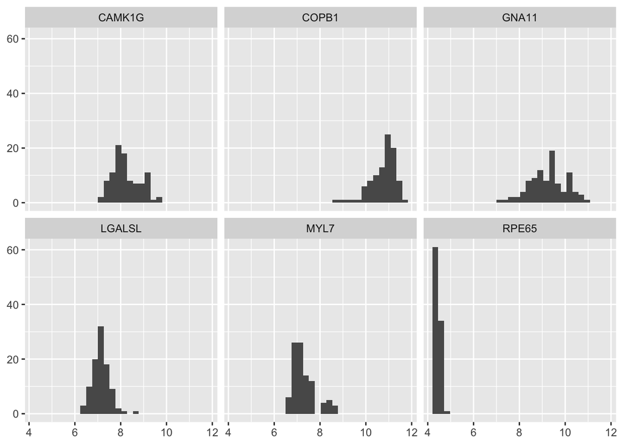

```r
tiss_ge_train_set %>%
  gather(gene, expression, all_of(genes6))  %>%
  ggplot(aes(x = expression)) +
  geom_histogram() +
  facet_wrap(~ gene) +
  xlab(NULL) + ylab(NULL)
```

The boxplots below plot gene expression against tissue type for the six genes. Note that setting `scales = 'free_y'` allows the y-axis to vary from plot to plot, so they are not on the same scale.

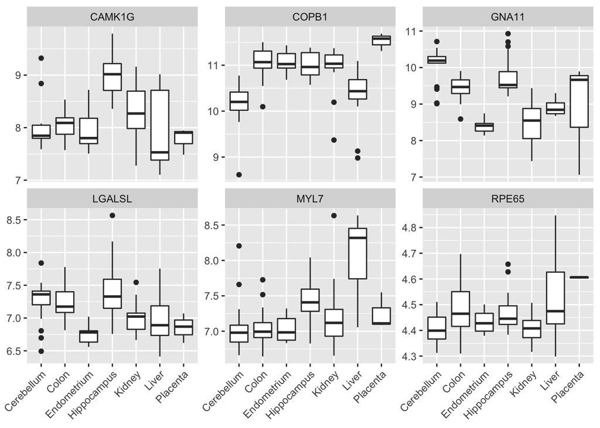

```r
tiss_ge_train_set %>%
  gather(gene, expression, all_of(genes6))  %>%
  ggplot(aes(x = y, y = expression)) +
  geom_boxplot() +
  facet_wrap(~ gene, scales = 'free_y') +
  xlab(NULL) + ylab(NULL) +
  scale_x_discrete(labels = str_to_title(unique(tiss_ge_train_set$y))) +
  theme(axis.text.x = element_text(angle = 45, hjust=1))
```

The `ggcorr` function from the `GGally` package makes pretty correlation matrix plots. Each tiny square in this plot represents the correlation between a pair of genes (out of the entire set of 100 genes). Red indicates positive correlation (close to 1), blue indicates negative correlation (close to -1), and white indicates no correlation (close to 0).

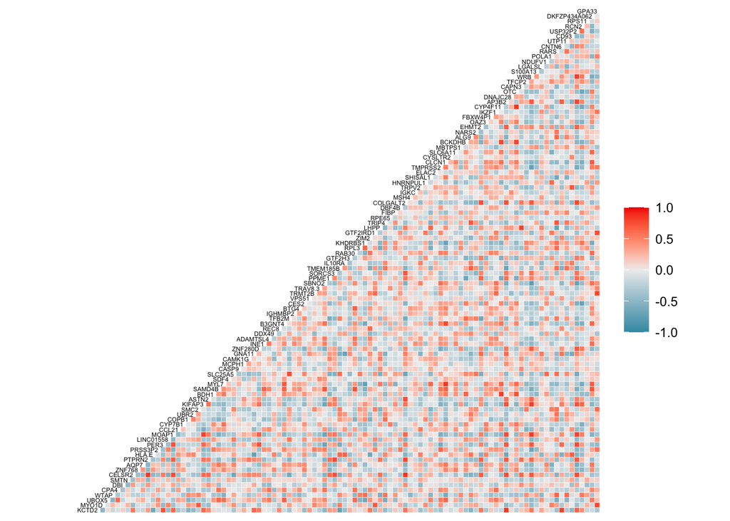

```r
ggcorr(tiss_ge_train_set[,-1], hjust = 1, size = 1.5, layout.exp = 10)
```

## Question 2

Using the `tree` function from the `tree` package and all of the training set gene expression data, build a decision tree to classify the tissue types. Get the predicted class labels for the test set data, report the test accuracy, and comment on the test confusion matrix.

## Question 3

Fit a bagging (bootstrap aggregation) model to the training data by running `randomForest` from the `randomForest` package with the `mtry` parameter set to the number of predictors (`mtry = 100`). Be sure to set a random seed so that your code is reproducible (the solutions use `set.seed(64)`). Get the predicted class labels for the test set data and report the test accuracy.

## Question 4

Now, build a random forest model with the `mtry` parameter set to the square root of the number of predictors. Also, set `importance = TRUE` so that the importance of the predictors is assessed. You will need the variable importance information for Q3.5. Be sure to set a random seed so that your code is reproducible (the solutions use `set.seed(81)`). Get the predicted class labels for the test set data and report the test accuracy.

## Question 5

Run the `importance` function on your random forest model from Q3.4 to extract variable importance measures for each of the tissue types. Find the five most important genes for classifying kidney tissues by ordering the Gini index measures. Compare these five genes with the genes that were used to construct the classification tree in Q3.2.